# Mobile Phone Usage and Loan Repayment: ML Club Chula Tournament 2

Charin Polpanumas

March 11, 2559 BE

# 1 Executive Summary

This report is a predictive analytics attempted to predict credit behavior (default vs non-default) of 1,000 Thai individuals from the `testing` set given a dataset of 1,000 individuals to work with for `training` and `validation` set. It is an answer to the [ML Club Chula Tournament 2](https://drive.google.com/file/d/0B1vlbhoEpEY8Z2wxMW9jUUFDVkE/view) by [ML Club Chula](https://www.facebook.com/MLClubChula/).

With respect to [Bjorkegen and Grissen (2015)](http://papers.ssrn.com/sol3/papers.cfm?abstract_id=2611775), we extracted features from call pattern, mobile payment pattern and demographics of the sample. Feature data was collected throughout 2014 and the response data was collected in the latter half of 2014.

We train random forest, svm with gaussian kernel and boosted logistic regression on the 60/40 training set, then validated resulting in random forest classifier having the largest AUC. We chose random forest to predict the testing set given.

Report [here](http://cstorm125.github.io/mobilecredit)

GitHub [here](https://github.com/cstorm125/mobilecredit)

# 2 Data Processing

## 2.1 Load Necessary Libraries

```r
library(jsonlite) #for reading json
library(plyr) #for data frame operations
library(caret) #for learning
library(lubridate) #for dates
library(AUC) #for AUC
library(DMwR) #for SMOTE
set.seed(1412) #set seed for replication
```

## 2.2 Download and Read Data

The data to train our learner is provided by [ML Club Chula](https://www.facebook.com/MLClubChula/).

```r
#Download, put them in data frames and save to RDS
if (!file.exists('data/call.json')){
    download.file(url='http://ec2-54-169-168-236.ap-southeast-1.compute.amazonaws.com/mlwc-tournament/trainingset/trainingset-api.php?tablename=cdrframe',destfile ='data/call.json')
    call <-fromJSON(txt='data/call.json')
    saveRDS(call,file='data/call.rds')
}
if (!file.exists('data/payment.json')){
    download.file(url='http://ec2-54-169-168-236.ap-southeast-1.compute.amazonaws.com/mlwc-tournament/trainingset/trainingset-api.php?tablename=paymentframe',destfile ='data/payment.json')
    payment <-fromJSON(txt='data/payment.json')
    saveRDS(payment,file='data/payment.rds')
}
if (!file.exists('data/profile.json')){
    download.file(url='http://ec2-54-169-168-236.ap-southeast-1.compute.amazonaws.com/mlwc-tournament/trainingset/trainingset-api.php?tablename=profileframe',destfile ='data/profile.json')
    profile <-fromJSON(txt='data/profile.json')
    saveRDS(profile,file='data/profile.rds')
}
if (!file.exists('data/response.json')){
    download.file(url='http://ec2-54-169-168-236.ap-southeast-1.compute.amazonaws.com/mlwc-tournament/trainingset/trainingset-api.php?tablename=responseframe',destfile ='data/response.json')
    response <-fromJSON(txt='data/response.json')
    saveRDS(response,file='data/response.rds')
}

#Read from RDS
call <- readRDS(file = 'data/call.rds')
payment <- readRDS(file = 'data/payment.rds')
profile <- readRDS(file = 'data/profile.rds')
response <- readRDS(file = 'data/response.rds')
```

## 2.3 Feature Extraction

### 2.3.1 Call Details

From the `call` dataset, we will engineer the following features for call variaty and mobility. Note that since the database is based on outgoing calls from our sample, we have little data on the calls our sample receives.

Our resulting features include:

- Sum of calls
- Mean, sum and standard deviation of duration of calls
- Sum of different numbers called
- Percentage of weekend calls
- Percentage of calls in the morning, afternoon, evening and at night
- Sum of different locations calls were made

```r
#Sum of calls
outgoing <- as.data.frame(table(call$callingnum))
colnames(outgoing) <-c('callingnum','outgoing')

#Mean duration
m_duration <-aggregate(duration ~ callingnum, data = call, mean)
colnames(m_duration) <-c('callingnum','m_duration')

#Sum duration
s_duration <-aggregate(duration ~ callingnum, data = call, sum)
colnames(s_duration) <-c('callingnum','s_duration')

#Sd duration
sd_duration <-aggregate(duration ~ callingnum, data = call, sd)
colnames(sd_duration) <-c('callingnum','sd_duration')

#Sum of different called numbers
dif_outgoing <- aggregate(callednum~callingnum, data = call, unique)
colnames(dif_outgoing) <-c('callingnum','callednum')
dif_outgoing$callednum <-sapply(dif_outgoing$callednum,length)

#Percentage of weekend calls
call$timestamp <-ymd_hms(call$timestamp)
call$weekday <-weekdays(call$timestamp)
call$weekend <-ifelse(call$weekday=='Sunday'|call$weekday=='Saturday',1,0)
weekend <- aggregate(weekend~callingnum, data = call, sum)
colnames(weekend) <-c('callingnum','weekend')
weekend$weekend<-weekend$weekend/outgoing$outgoing

#Percentages of calls in morning, afternoon, evening, night
#Set the quarters
call$hour <-hour(call$timestamp)
call$morning <- ifelse(call$hour>=6 & call$hour<12,1,0)
call$afternoon<- ifelse(call$hour>=12 & call$hour<18,1,0)
call$evening<- ifelse(call$hour>= 18& call$hour<=23,1,0)
call$night<- ifelse(call$hour>=0 & call$hour<6,1,0)

#Aggregate the quarters
#Morning
morning <- aggregate(morning~callingnum, data = call, sum)
colnames(morning) <-c('callingnum','morning')
morning$morning<-morning$morning/outgoing$outgoing
#Afternoon
afternoon <- aggregate(afternoon~callingnum, data = call, sum)
colnames(afternoon) <-c('callingnum','afternoon')
afternoon$afternoon<-afternoon$afternoon/outgoing$outgoing
#evening
evening <- aggregate(evening~callingnum, data = call, sum)
colnames(evening) <-c('callingnum','evening')
evening$evening<-evening$evening/outgoing$outgoing
#night
night <- aggregate(night~callingnum, data = call, sum)
colnames(night) <-c('callingnum','night')
night$night<-night$night/outgoing$outgoing

#Sum of different call locations
dif_location <- aggregate(location~callingnum, data = call, unique)
colnames(dif_location) <-c('callingnum','location')
dif_location$location <-sapply(dif_location$location,length)
```

### 2.3.2 Payment

From the `payment` dataset, we will engineer the following features for payment pattern:

- Percentage of INACTIVE
- Mean, sum and standard deviation of top-up
- Mean, sum and standard deviation of spending
- Mean and standard deviation of balance

```r
#Percentage of INACTIVE
payment$inactive <- ifelse(payment$status=='INACTIVE',1,0)
payment$active <- ifelse(payment$status=='ACTIVE',1,0)
s_active <-aggregate(active ~ callingnum, data = payment, sum)
s_inactive<-aggregate(inactive ~ callingnum, data = payment, sum)
s_per_inactive <-merge(s_active,s_inactive,by='callingnum')
s_per_inactive$per_inactive<-s_per_inactive$inactive/(s_per_inactive$active+s_per_inactive$inactive)

#Mean topup
m_topup <- aggregate(topup ~ callingnum, data = payment, mean)
colnames(m_topup) <-c('callingnum','m_topup')

#Mean spending
m_spend <-aggregate(spending ~ callingnum, data = payment, mean)
colnames(m_spend) <-c('callingnum','m_spend')

#Mean balance
m_balance <-aggregate(balance ~ callingnum, data = payment, mean)
colnames(m_balance) <-c('callingnum','m_balance')

#Sum topup
s_topup <- aggregate(topup ~ callingnum, data = payment, sum)
colnames(s_topup) <-c('callingnum','s_topup')

#Sum spending
s_spend <-aggregate(spending ~ callingnum, data = payment, sum)
colnames(s_spend) <-c('callingnum','s_spend')

#sd topup
sd_topup <- aggregate(topup ~ callingnum, data = payment, sd)
colnames(sd_topup) <-c('callingnum','sd_topup')

#sd spending
sd_spend <-aggregate(spending ~ callingnum, data = payment, sd)
colnames(sd_spend) <-c('callingnum','sd_spend')

#sd balance
sd_balance <-aggregate(balance ~ callingnum, data = payment, sd)
colnames(sd_balance) <-c('callingnum','sd_balance')
```

### 2.3.3 Profile

From the `profile` dataset, we create the `age` feature.

```r
#Age in days
profile$age <-as.numeric(Sys.time()-ymd(profile$birthdate))

#Remove unnecessary features
profile<-subset(profile, select=-c(birthdate,paytype))
```

### 2.3.4 Putting It Together

We then combine all feature data frames and remove `id` and `callingnum`, which are irrelevant to the analysis.

```r
df <- arrange(profile,phonenum)
colnames(df)<-c('id','callingnum','gender','province','age')
df<-join_all(list(df, outgoing,m_duration,s_duration,sd_duration,dif_outgoing,
                  weekend,morning,afternoon,evening,night,dif_location,s_per_inactive,
                  m_topup,m_spend,m_balance,s_topup,s_spend,sd_topup,sd_spend,sd_balance,response))

#Factorize characters
df$gender<-as.factor(df$gender)
df$status<-as.factor(df$status)
df$province<-as.factor(df$province)

#Remove unnecessary features
df <- subset(df, select=-c(id,callingnum))
```

# 3 Model

Separate data into `training` and `validation` sets at 60/40 ratio.

```r
inTrain <- createDataPartition(df$status,p=0.6,list=FALSE)
training<-df[inTrain,]
validation<-df[-inTrain,]
```

Create a SMOTEd training set to improve class imbalance. The new training set has a distribution of both class as follows.

```r
new_training=SMOTE(status~.,training,perc.over = 200,perc.under=200)
table(new_training$status)
```

```
##
##   0   1
## 400 300
```

Train a `random forest`, `svm with gaussian kernel` and `boosted logistic regression` classifier.

```r
fit1<-train(status~.,data=new_training, method='rf')
fit2<-train(status~.,data=new_training, method='svmRadial')
fit3<-train(status~.,data=new_training, method='LogitBoost')
```

The variable importance of top-ten most influential variables for random forest, svm with gaussian kernel and boosted logistic regression are shown below.

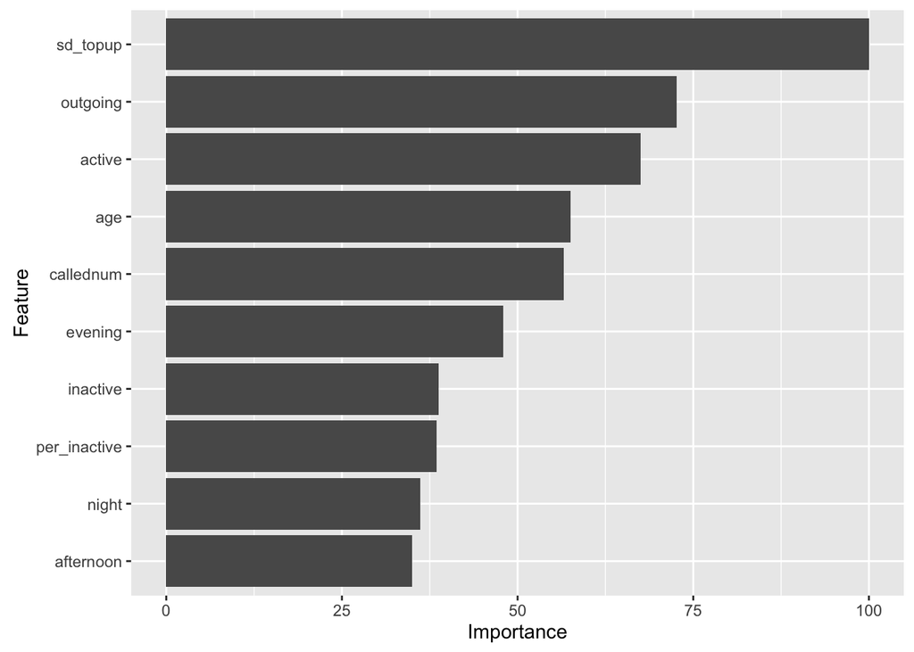

```r
ggplot(varImp(fit1),top=10)
```

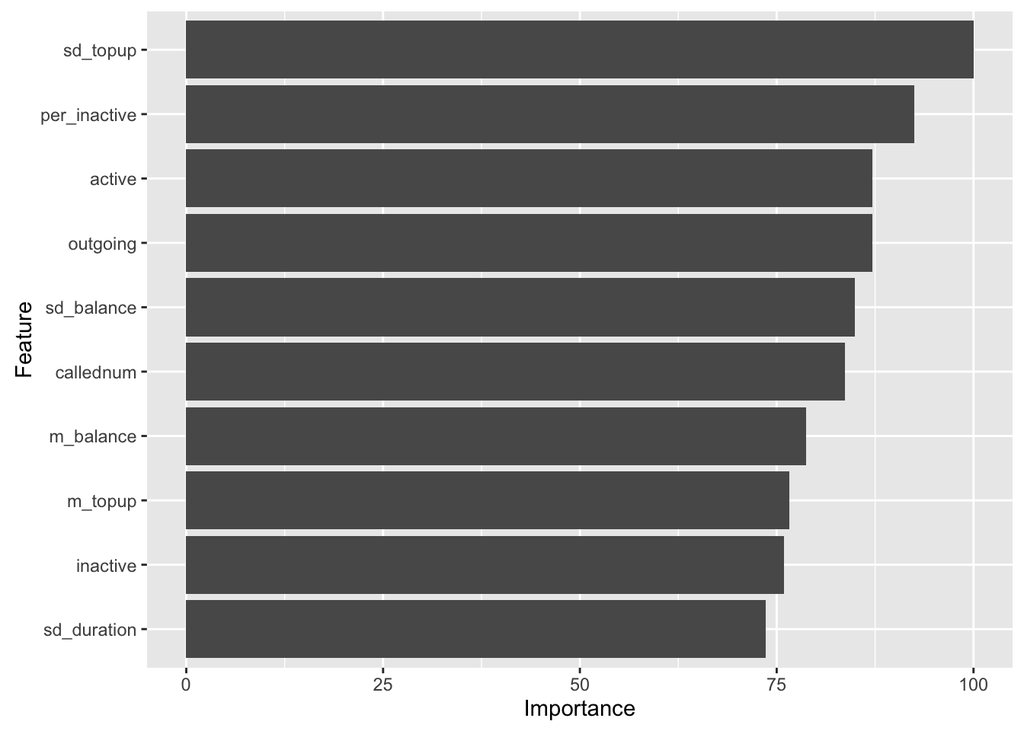

```r
ggplot(varImp(fit2),top=10)
```

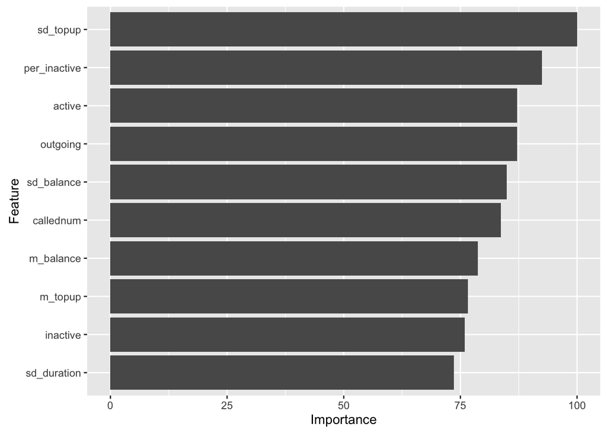

```r
ggplot(varImp(fit3),top=10)
```

Area under the ROC curve for the `validation` set is as follows.

```r
#Predict
pred1<-predict(fit1,newdata=validation)
pred2<-predict(fit2,newdata=validation)
pred3<-predict(fit3,newdata=validation)
#AUC
auc(roc(pred1,validation$status))
```

```
## [1] 0.6523342
```

```r
auc(roc(pred2,validation$status))
```

```
## [1] 0.517472
```

```r
auc(roc(pred3,validation$status))
```

```
## [1] 0.6122031
```

# 4 Testing

As a result of validation, `random forest` has the best AUC performance in `validation` set and thus we use it as our model for the `testing` set. Using the `testing` dataset provided by [ML Club Chula](https://www.facebook.com/MLClubChula/). The resulting dataset is a probability of label equals to 1 for a given profile ID.

```r
#load
testing<-readRDS(file = 'testing/test.rds')
#Predict
pred<-predict(fit1,newdata=testing,type='prob')

#Create submission file
pd<-pred$`1`
profile_id<-as.character(testing$id)
result<-cbind(profile_id,pd)
result
```

```
##         profile_id pd
##    [1,] "T210254"  "0.472"
##    [2,] "T210609"  "0.114"
##    [3,] "T210481"  "0.174"
##    [4,] "T210362"  "0.068"
##    [5,] "T210482"  "0.404"
##    [6,] "T210276"  "0.096"
##    [7,] "T210010"  "0.102"
##    [8,] "T210334"  "0.422"
##    [9,] "T210447"  "0.594"
##   [10,] "T210432"  "0.366"
##   [11,] "T210534"  "0.082"
##   [12,] "T210242"  "0.312"
##   [13,] "T210471"  "0.144"
##   [14,] "T210375"  "0.524"
```

[output cut: 986 more lines]

```r
#Write to submission2.csv
write.csv(result,'submission2.csv')
```